# Models Rmd

### Posterior Check

```r
post <- extract.samples(m2.3)
```

- Since I haven’t touched hidden parameters since, I do not check them here.

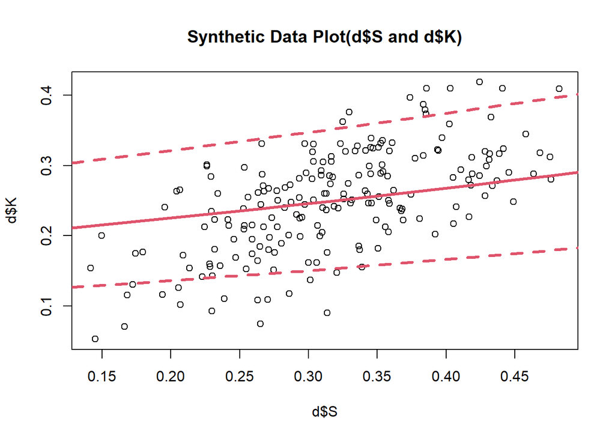

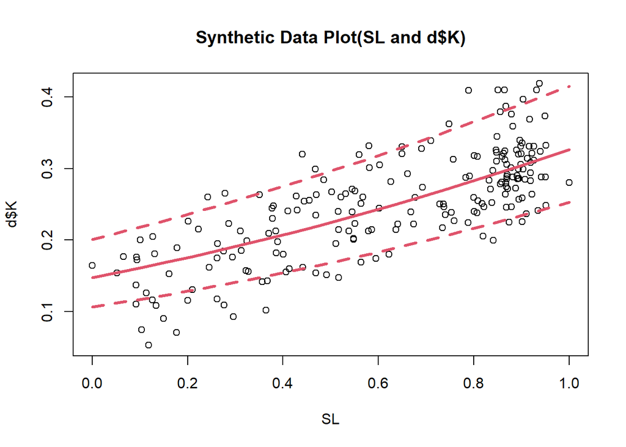

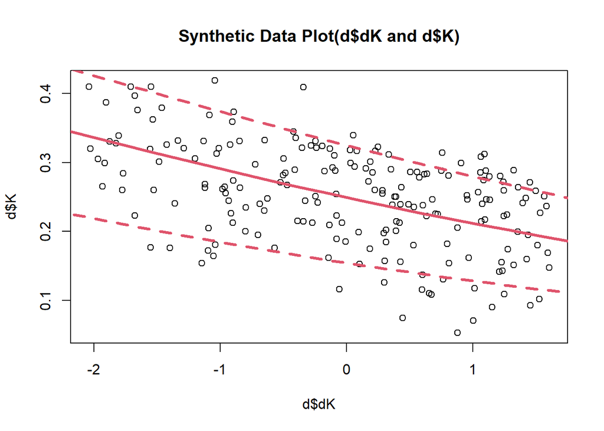

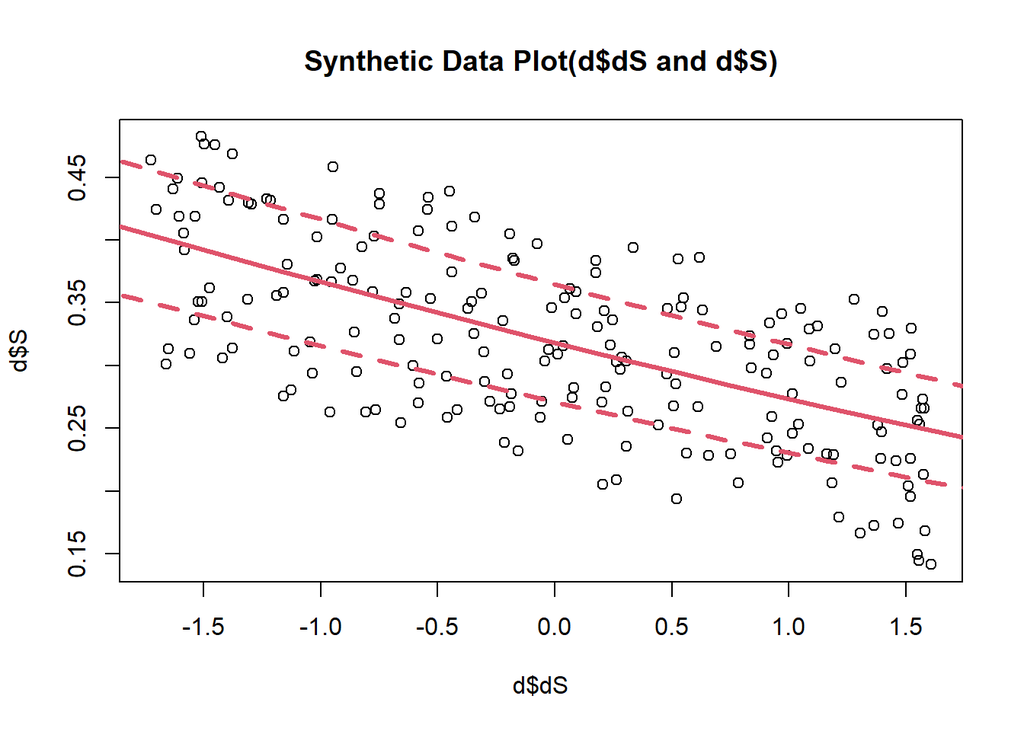

```r
plot(d$S, d$K, main = "Synthetic Data Plot(d$S and d$K)")
Sseq<-seq(0, 0.5, len = 20)
KbyS<- sapply(Sseq, # Tricky but t and t to calculate estimates by group, though dK does not have group so do not need
    function (i) inv_logit(post$aK + post$bK_S * i + t(t(post$bK_SL) * colMeans(post$SL)) + rep(post$bK_dK, 25) * d$dK ))
means<- apply( KbyS , 2 , mean )
PIs<- apply( KbyS , 2 , PI )
lines(Sseq, means, col = 2, lwd = 3)
lines(Sseq, PIs[1, ], col = 2, lty = 2, lwd = 3)
lines(Sseq, PIs[2, ], col = 2, lty = 2, lwd = 3)


plot(SL, d$K, main = "Synthetic Data Plot(SL and d$K)")
SLseq<-seq(0, 1, len = 20)
KbySL<- sapply(SLseq,
    function (i) inv_logit(post$aK + t(t(post$bK_S) * d$S) + post$bK_SL * i + rep(post$bK_dK, 25) * d$dK ))
means<- apply( KbySL , 2 , mean )
PIs<- apply( KbySL , 2 , PI )
lines(SLseq, means, col = 2, lwd = 3)
lines(SLseq, PIs[1, ], col = 2, lty = 2, lwd = 3)
lines(SLseq, PIs[2, ], col = 2, lty = 2, lwd = 3)


plot(d$dK, d$K, main = "Synthetic Data Plot(d$dK and d$K)")
dKseq<-seq(-2.5, 2, len = 20)
KbydK<- sapply(dKseq,
    function (i) inv_logit(post$aK + t(t(post$bK_S) * d$S) + t(t(post$bK_SL) * colMeans(post$SL)) + rep(post$bK_dK, 25) * i ))
PIs<- apply( KbydK , 2 , PI )
means<- apply( KbydK , 2 , mean )
lines(dKseq, means, col = 2, lwd = 3)
lines(dKseq, PIs[1, ], col = 2, lty = 2, lwd = 3)
lines(dKseq, PIs[2, ], col = 2, lty = 2, lwd = 3)

# Model S

plot(d$dS, d$S, main = "Synthetic Data Plot(d$dS and d$S)")
dSseq<-seq(-2, 2, len = 20)
SbydS<- sapply(dSseq,
    function (i) inv_logit(post$aS + rep(post$bS_dS, 25) * i )) # Used mean of each simulated data
PIs<- apply( SbydS , 2 , PI )
means<- apply( SbydS , 2 , mean )
lines(dSseq, means, col = 2, lwd = 3)
lines(dSseq, PIs[1, ], col = 2, lty = 2, lwd = 3)
lines(dSseq, PIs[2, ], col = 2, lty = 2, lwd = 3)
```

### Compare Models

```r
# Compare models
model_comparison <- compare(m1.3, m2.3)
print(model_comparison)
```

```
##           WAIC       SE    dWAIC      dSE    pWAIC       weight
## m2.3 -878.6165 17.38030   0.0000       NA 64.83266 1.000000e+00
## m1.3 -716.9546 19.79697 161.6619 14.06001 34.47477 7.862526e-36
```

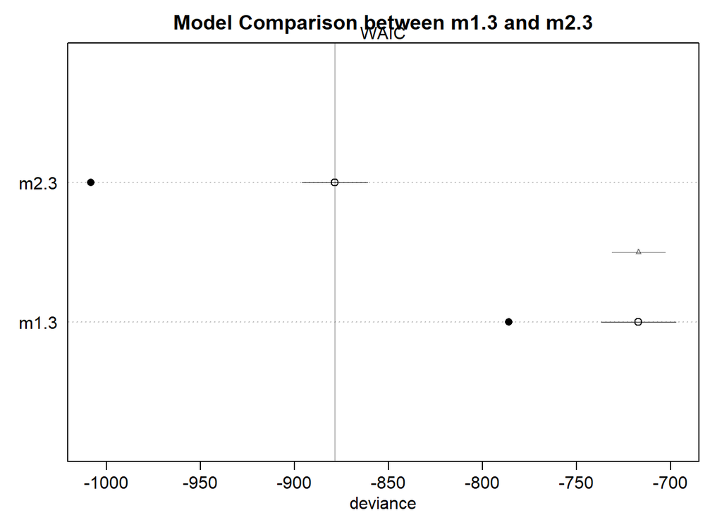

```r
# Plot WAIC/PSIS differences
plot(model_comparison, main = "Model Comparison between m1.3 and m2.3")
```

#### Key Columns in the compare Output:

- WAIC / PSIS: Lower values indicate better out-of-sample predictive accuracy.
- dWAIC / dPSIS: The difference in information criteria between the current model and the top-ranked (best) model.
- dSE: If the standard error is large relative to the difference, the two models have statistically indistinguishable predictive capacities.
- weight: The Akaike weight, which represents the relative probability or evidence that a given model will make the best predictions among the set of compared models

=> Therefore, the model 2.3 is better than the other one with lower WAIC, and so on…

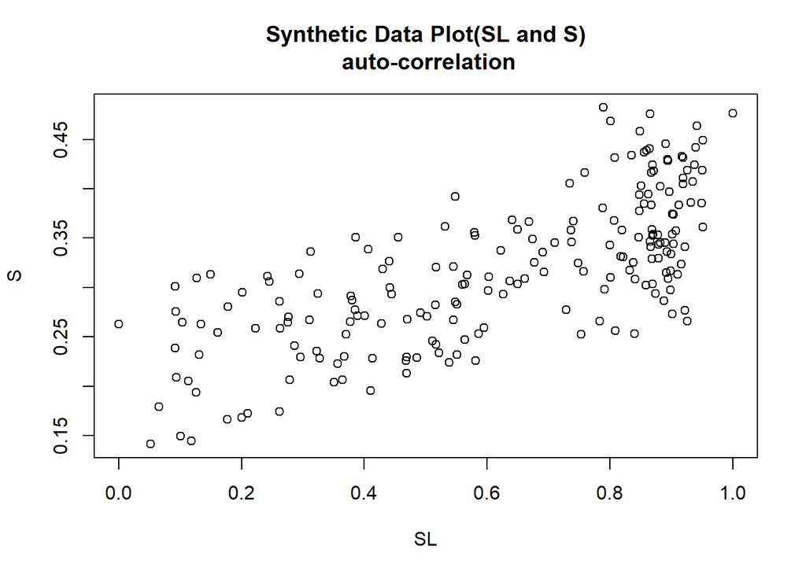

```r
plot(SL, S, main = "Synthetic Data Plot(SL and S)\n auto-correlation")
```

This is because there is an auto-correlation!!

## Model 3 (m3)

- see priors in overview.pdf, but this include correlation between SL and S.
- Instead, this does not include multilevel model of Y -> S, because the information is in correlation.
- This code is based on the Ch 14.3 in Statistical Rethinking as SL and S are not centred

```r
# Model 3
m3<- ulam(
    alist (
    # Main model K
        K ~ normal(mu_K, U),
        logit(mu_K) <- aK[T] + bK_S[T] * S + bK_SL[T] * SL[i] + bK_Y[T] * Y[i] + bK_dK * dK,

        # In this case (m3), we do include correlation between S and SL due to Y.
        vector[25]: aK <- aK_bar + sigma_aK * z_aK[T],
        vector [25]: bK_Y <- bK_Y_bar + sigma_bK_Y * z_bK_Y[T],
        c(aK_bar, bK_Y_bar)~normal(0,0.3),
        c(sigma_aK, sigma_bK_Y) ~ exponential(6),
        z_aK[T]~normal(0,0.1),
        z_bK_Y[T] ~ normal(0,0.1),

        transpars>vector[25]:bK_S <<- v[,1],
        transpars>vector[25]:bK_SL <<- v[,2],

        transpars>matrix[25, 2]:v <- compose_noncentered(sigmaSSL, RhoSSL, zSSL),
        vector[2]: sigmaSSL ~ exponential(2),
        cholesky_factor_corr[2]:RhoSSL ~ lkj_corr_cholesky(1), # I do not expect very very strong correlation.
        matrix[2,25]: zSSL ~ normal(0 , 1),

        # don't need regularization
        bK_dK ~ normal(0, 0.3),
        U ~ exponential(1),

    # Model S
        # This is correlation so I do not include multi-model of Y-> S
        S ~ normal(mu_S, sigma_S),
        logit(mu_S) <- aS[T] + bS_dS * dS ,

        vector[25]: aS<-aS_bar + sigma_aS * z_aS[T],
        aS_bar ~ normal(0,0.3),
        sigma_aS ~ exponential(6),
        z_aS[T] ~ normal(0,0.1),

        bS_dS ~ normal(0,0.3),
        sigma_S ~ exponential(1),

    # Model SL by Y
        vector[200]: SL ~ normal(inv_logit(6 * Y - 2) - 0.04, 0.05),

    # Model T, This should be hard coded based on the previous research
        T ~ poisson(Y * 25),

    # Model T by Y
        vector[200]:Y ~ normal( 0.5, 0.2)
    ), dat = d, constraints = list(
        SL    = "lower=0,upper=1",
        Y    = "lower=0,upper=1"
    ), chains=4, cores=4, iter= 4000, warmup = 2000, log_lik=TRUE, max_treedepth = 13, control = list(
    adapt_delta = 0.99
  )
)
```

[output not shown]

[output not shown]

[output not shown]

[output not shown]

```
## Running MCMC with 4 parallel chains, with 1 thread(s) per chain...
##
## Chain 1 Iteration:    1 / 4000 [  0%]  (Warmup)
```

[output not shown]

[output not shown]

[output not shown]

[output not shown]

```
## Chain 1
```

```
## Chain 2 Iteration:    1 / 4000 [  0%]  (Warmup)
```

[output not shown]

[output not shown]

[output not shown]

[output not shown]

```
## Chain 2
```

```
## Chain 3 Iteration:    1 / 4000 [  0%]  (Warmup)
```

[output not shown]

[output not shown]

[output not shown]

[output not shown]

```
## Chain 3
```

[output not shown]

[output not shown]

[output not shown]

[output not shown]

```
## Chain 3
```

[output not shown]

[output not shown]

[output not shown]

[output not shown]

```
## Chain 3
```

```
## Chain 4 Iteration:    1 / 4000 [  0%]  (Warmup)
```

[output not shown]

[output not shown]

[output not shown]

[output not shown]

```
## Chain 4
```

[output not shown]

[output cut: 117 more lines]

```
## Chain 1 Iteration: 3400 / 4000 [ 85%]  (Sampling)
## Chain 3 Iteration: 3900 / 4000 [ 97%]  (Sampling)
## Chain 1 Iteration: 3500 / 4000 [ 87%]  (Sampling)
## Chain 3 Iteration: 4000 / 4000 [100%]  (Sampling)
## Chain 3 finished in 121.6 seconds.
## Chain 1 Iteration: 3600 / 4000 [ 90%]  (Sampling)
## Chain 1 Iteration: 3700 / 4000 [ 92%]  (Sampling)
## Chain 1 Iteration: 3800 / 4000 [ 95%]  (Sampling)
## Chain 1 Iteration: 3900 / 4000 [ 97%]  (Sampling)
## Chain 1 Iteration: 4000 / 4000 [100%]  (Sampling)
## Chain 1 finished in 131.4 seconds.
##
## All 4 chains finished successfully.
## Mean chain execution time: 118.3 seconds.
## Total execution time: 131.5 seconds.
```

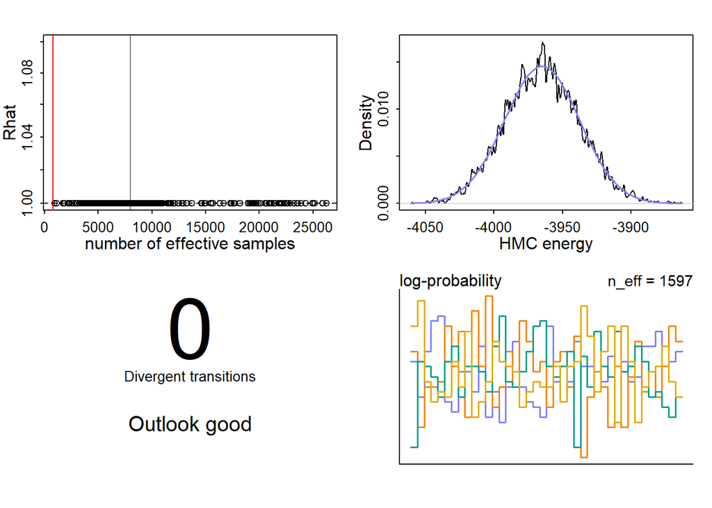

```r
dashboard(m3)
```

```r
# Model 3.2
m3.2<- ulam(
    alist (
    # Main model K
        K ~ normal(mu_K, U),
        logit(mu_K) <- aK[T] + bK_S[T] * S + bK_SL[T] * SL[i] + bK_dK * dK,
        vector[25]: aK <- aK_bar + sigma_aK * z_aK[T],
        aK_bar~normal(0,0.3),
        sigma_aK ~ exponential(6),
        z_aK[T]~normal(0,0.1),
        transpars>vector[25]:bK_S <<- v[,1],
        transpars>vector[25]:bK_SL <<- v[,2],
        transpars>matrix[25, 2]:v <- compose_noncentered(sigmaSSL, RhoSSL, zSSL),
        vector[2]: sigmaSSL ~ exponential(2),
        cholesky_factor_corr[2]:RhoSSL ~ lkj_corr_cholesky(1),
        matrix[2,25]: zSSL ~ normal(0 , 1),
        bK_dK ~ normal(0, 0.3),
        U ~ exponential(1),

    # Model S
        S ~ normal(mu_S, sigma_S),
        logit(mu_S) <- aS[T] + bS_dS * dS ,
        vector[25]: aS<-aS_bar + sigma_aS * z_aS[T],
        aS_bar ~ normal(0,0.3),
        sigma_aS ~ exponential(6),
        z_aS[T] ~ normal(0,0.1),
        bS_dS ~ normal(0,0.1),
        sigma_S ~ exponential(1),

    # Model SL by Y
        vector[200]: SL ~ normal(inv_logit(6 * Y - 2) - 0.04, 0.05),

    # Model T
        T ~ poisson(Y * 25),

    # Model T by Y
        vector[200]:Y ~ normal( 0.5, 0.2)
    ), dat = d, constraints = list(
        SL    = "lower=0,upper=1",
        Y    = "lower=0,upper=1"
    ), chains=4, cores=4, iter= 4000, warmup = 2000, log_lik=TRUE, max_treedepth = 13, control = list(
    adapt_delta = 0.99
  )
)
```

```
## Running MCMC with 4 parallel chains, with 1 thread(s) per chain...
##
## Chain 1 Iteration:    1 / 4000 [  0%]  (Warmup)
```

```
## Chain 2 Iteration:    1 / 4000 [  0%]  (Warmup)
```

```
## Chain 3 Iteration:    1 / 4000 [  0%]  (Warmup)
```

```
## Chain 4 Iteration:    1 / 4000 [  0%]  (Warmup)
```

[output not shown]

[output cut: 117 more lines]

```
## Chain 1 Iteration: 3800 / 4000 [ 95%]  (Sampling)
## Chain 3 Iteration: 3500 / 4000 [ 87%]  (Sampling)
## Chain 1 Iteration: 3900 / 4000 [ 97%]  (Sampling)
## Chain 1 Iteration: 4000 / 4000 [100%]  (Sampling)
## Chain 1 finished in 100.5 seconds.
## Chain 3 Iteration: 3600 / 4000 [ 90%]  (Sampling)
## Chain 3 Iteration: 3700 / 4000 [ 92%]  (Sampling)
## Chain 3 Iteration: 3800 / 4000 [ 95%]  (Sampling)
## Chain 3 Iteration: 3900 / 4000 [ 97%]  (Sampling)
## Chain 3 Iteration: 4000 / 4000 [100%]  (Sampling)
## Chain 3 finished in 112.2 seconds.
##
## All 4 chains finished successfully.
## Mean chain execution time: 96.7 seconds.
## Total execution time: 112.3 seconds.
```

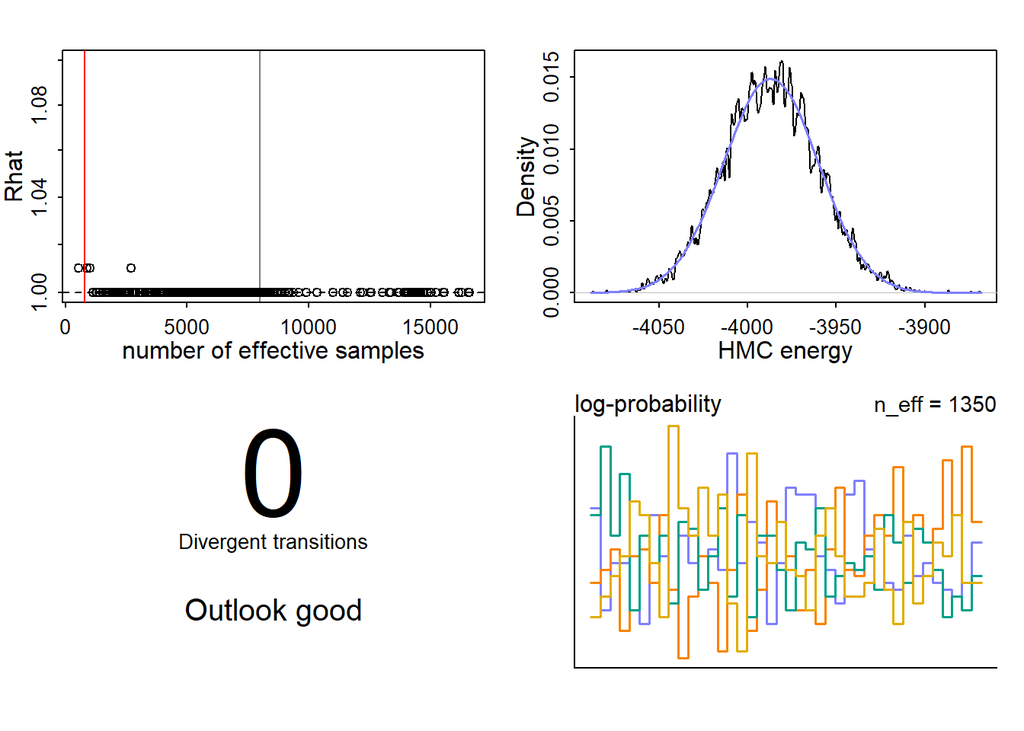

```r
dashboard(m3.2)
```

```r
precis(m3.2, depth=1)
```

```
##                 mean          sd        5.5%       94.5%     rhat  ess_bulk
## aK_bar   -1.41944332 0.076591404 -1.54349971 -1.30153606 1.000679  3251.700
## sigma_aK  0.18582062 0.192406916  0.01007776  0.54973251 1.000330  7932.935
## bK_dK    -0.21297122 0.012028468 -0.23189497 -0.19362895 1.000173 14453.760
## U         0.02959372 0.002128476  0.02620144  0.03303852 1.003730  1148.894
## aS_bar   -0.74573040 0.035770138 -0.80173386 -0.68852240 1.000407  4466.261
## sigma_aS  1.28891601 0.241869151  0.93106256  1.70201259 1.000209  4352.732
## bS_dS    -0.21183929 0.015662998 -0.23645463 -0.18683375 1.000223 15041.525
## sigma_S   0.04673647 0.002568441  0.04283362  0.05099919 1.000269  9586.839
```

- This model is good enough.

### Posterior Check

```r
post <- extract.samples(m3.2)
```

- I do not check the Hidden parameters since I have never touched it since m1

#### Correlation?

- Rho value shows a bit of correlation between S and SL.

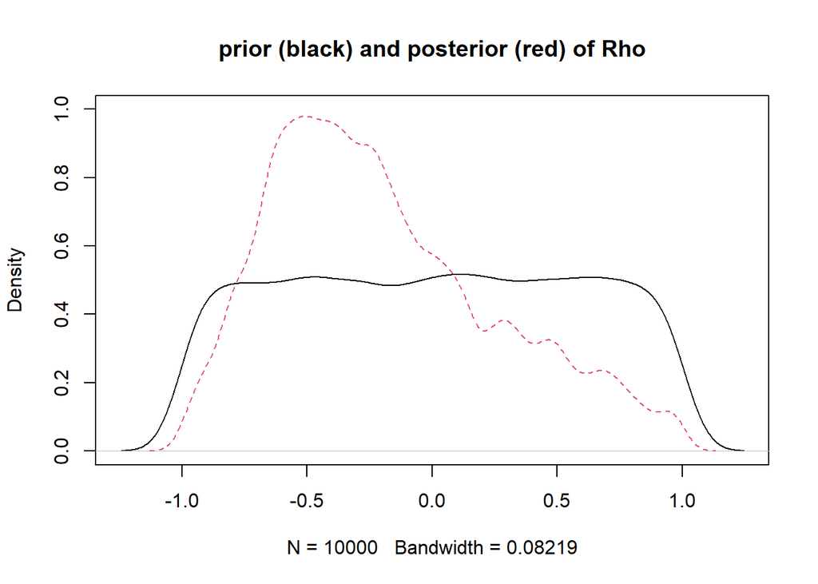

```r
R <- rlkjcorr( 1e4 , K=2 , eta=1 )# eta min lkj_corr()
plot(density( R[,1,2]), ylim = c(0, 1), main = "prior (black) and posterior (red) of Rho")
# This is complicated as cholesky correlation
true_rho_samples=NULL
for (i in 1:2000) {
  L <- post$RhoSSL[i, , ]
  R <- L %*% t(L)
  true_rho_samples[i] <- R[1, 2]
}
dens(true_rho_samples, add = TRUE, lty = 2, col = 2)
```

#### Posterior Predictions

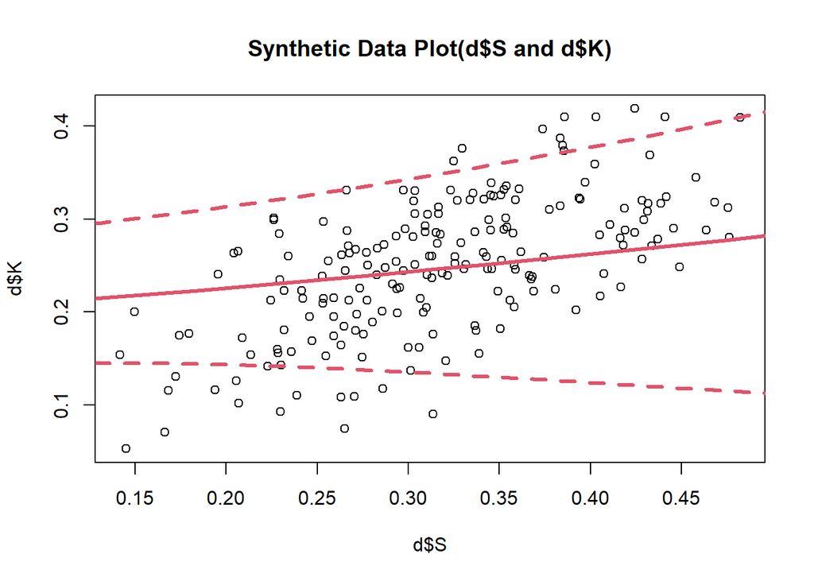

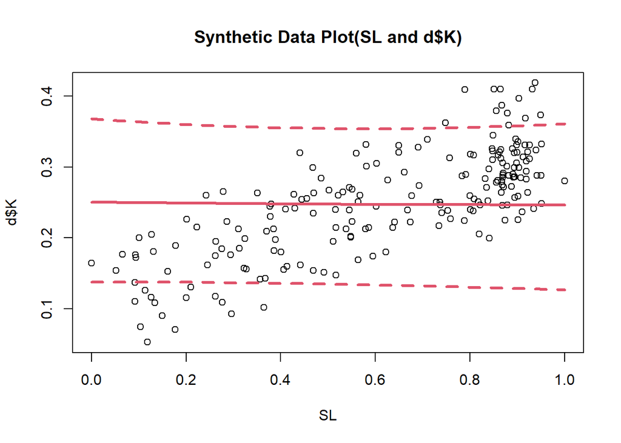

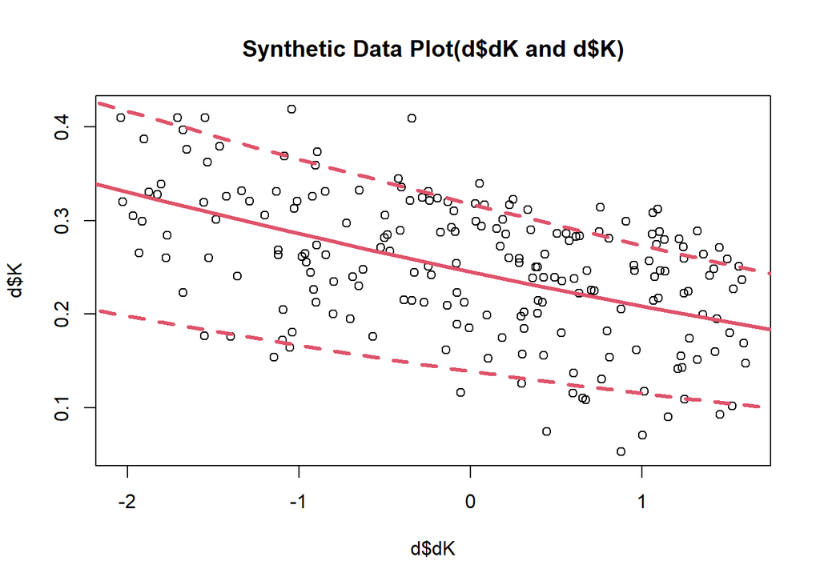

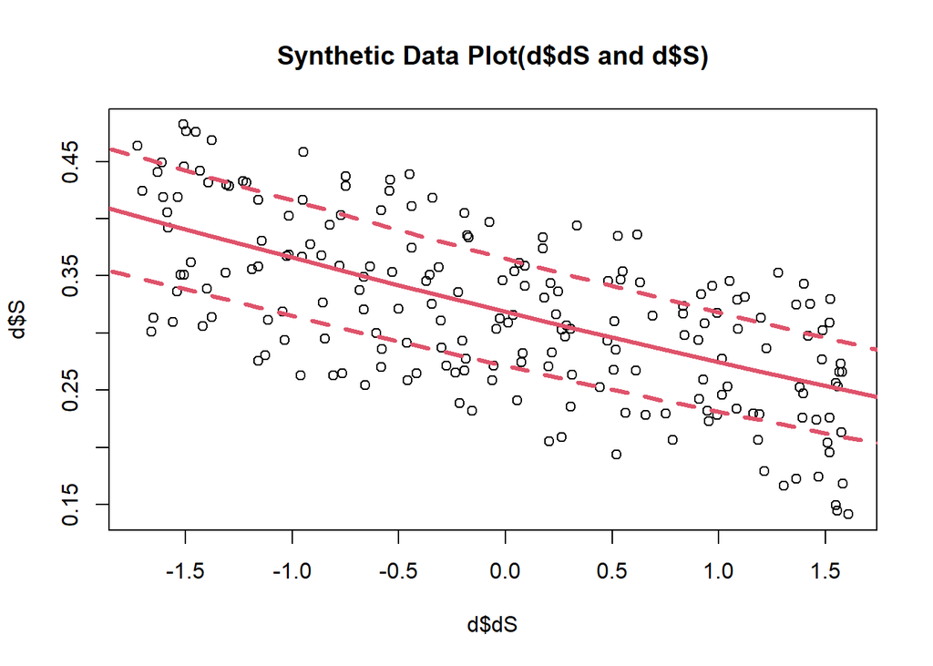

```r
plot(d$S, d$K, main = "Synthetic Data Plot(d$S and d$K)")
Sseq<-seq(0, 0.5, len = 20)
KbyS<- sapply(Sseq, # Tricky but t and t to calculate estimates by group, though dK does not have group so do not need
    function (i) inv_logit(post$aK + post$bK_S * i + t(t(post$bK_SL) * colMeans(post$SL)) + rep(post$bK_dK, 25) * d$dK ))
means<- apply( KbyS , 2 , mean )
PIs<- apply( KbyS , 2 , PI )
lines(Sseq, means, col = 2, lwd = 3)
lines(Sseq, PIs[1, ], col = 2, lty = 2, lwd = 3)
lines(Sseq, PIs[2, ], col = 2, lty = 2, lwd = 3)


plot(SL, d$K, main = "Synthetic Data Plot(SL and d$K)")
SLseq<-seq(0, 1, len = 20)
KbySL<- sapply(SLseq,
    function (i) inv_logit(post$aK + t(t(post$bK_S) * d$S) + post$bK_SL * i + rep(post$bK_dK, 25) * d$dK ))
means<- apply( KbySL , 2 , mean )
PIs<- apply( KbySL , 2 , PI )
lines(SLseq, means, col = 2, lwd = 3)
lines(SLseq, PIs[1, ], col = 2, lty = 2, lwd = 3)
lines(SLseq, PIs[2, ], col = 2, lty = 2, lwd = 3)


plot(d$dK, d$K, main = "Synthetic Data Plot(d$dK and d$K)")
dKseq<-seq(-2.5, 2, len = 20)
KbydK<- sapply(dKseq,
    function (i) inv_logit(post$aK + t(t(post$bK_S) * d$S) + t(t(post$bK_SL) * colMeans(post$SL)) + rep(post$bK_dK, 25) * i ))
PIs<- apply( KbydK , 2 , PI )
means<- apply( KbydK , 2 , mean )
lines(dKseq, means, col = 2, lwd = 3)
lines(dKseq, PIs[1, ], col = 2, lty = 2, lwd = 3)
lines(dKseq, PIs[2, ], col = 2, lty = 2, lwd = 3)

# Model S
plot(d$dS, d$S, main = "Synthetic Data Plot(d$dS and d$S)")
dSseq<-seq(-2, 2, len = 20)
SbydS<- sapply(dSseq,
    function (i) inv_logit(post$aS + rep(post$bS_dS, 25) * i )) # Used mean of each simulated data
PIs<- apply( SbydS , 2 , PI )
means<- apply( SbydS , 2 , mean )
lines(dSseq, means, col = 2, lwd = 3)
lines(dSseq, PIs[1, ], col = 2, lty = 2, lwd = 3)
lines(dSseq, PIs[2, ], col = 2, lty = 2, lwd = 3)
```

let me compare all those models.